# Gene clustering across multiple sample groups

Jim Zhang

2016-02-08

# Project background

## Title

Response of juvenile mice to spinal cord injury

## Description

This project uses gene expression microarray data to track transcriptome of young mice after spinal cord injury. Measurements were made in control and 5 time points after injury from 6 hours to 2 weeks. The goal of this analysis is to identify gene clusters that were signficantly different across time points.

# Samples and methods

## Samples

There are a total of 18 samples. Click here to view full table of samples

## Processing of microarray data

All [Affymetrix](http://www.affymetrix.com) probes were re-grouped into unique Entrez gene IDs using custom library file downloaded from [BRAINARRAY](http://brainarray.mbni.med.umich.edu) database. The raw data in .CEL files were normalized and summarized by [RMA](http://www.ncbi.nlm.nih.gov/pubmed/12925520) (Robust Multichip Averaging) method to generate an N by M matrix, where N is the number of unique Entrez genes and M is the number of samples. The normalized data were log2-transformed to get final measurements mostly ranging between 1 and 16, so every increase or decrease of the measurements by 1.0 corresponds to a 2-fold difference. All data processing steps were performed within the [R](https://www.r-project.org) environment. The following customized code can be applied to any types of [Affymetrix](http://www.affymetrix.com/estore/browse/level_three_category_and_children.jsp?category=35868&categoryIdClicked=35868&expand=true&parent=35617) platforms (3’IVT, Exon, Gene, etc.) as long as the raw data were stored in [CEL](http://media.affymetrix.com/support/developer/powertools/changelog/gcos-agcc/cel.html) format and [BRAINARRAY](http://brainarray.mbni.med.umich.edu/Brainarray/Database/CustomCDF/CDF_download.asp) provides the custom library file in CDF format.

## Preparation of data for gene clustering

Processed microarray data set were re-scaled to make the mean and standard deviation of each gene equal to 0 and 1.0. Control samples were not included for this analysis because they are very different from all the injuried samples, and the difference will dominate the analysis.

## Selection of differentially expressed gene

ANOVA was applied to give each gene a p value for its differential expression across sample groups. Corresponding false discovery rate was calculated using the p values. Genes for clustering analysis were sequentially selected by FDR, p value, and range (difference between maximum and minimum). The selection would be stopped if the number of qualifying genes was already smaller than a given minimal number.

## Gene set enrichment analysis

We made a comprehensive collection of predefined gene sets from difference resources such as [KEGG](http://www.genome.jp/kegg/) and [BioSystems](http://www.ncbi.nlm.nih.gov/biosystems). The collection was precompiled into an R data object. An example of such of an object can be downloaded from [here](https://github.com/zhezhangsh/DEGandMore/blob/master/examples/DeReport/default_set_human_5-1000.rds?raw=true).

# Analysis and results

## ANOVA analysis of each gene across sample

We applied ANOVA analysis on each gene to test its differential expression across samples of different groups.

- There are 13877 total genes
- There are 18 total samples
- There are 5 sample groups: 6Hr, 1day, 3day, 7day, 14day

Click here to view full ANOVA result table.

## Gene clustering

### Select genes differentially expressed across groups

Select genes using the following steps:

1. Select genes with FDR less than 0.2
2. Stop if less than 500 genes were left; otherwise, select those with ANOVA p values less than 0.01
3. Stop if less than 500 genes were left; otherwise, select those with range (*max-min*) greater than 2
4. If there are still more than 2000 genes left, select the top 2000 with the biggest ranges

A total of **975** genes were selected. The genes were used for the next step to identify gene clusters

**Figure** Hierarchical clustering of samples using all genes.

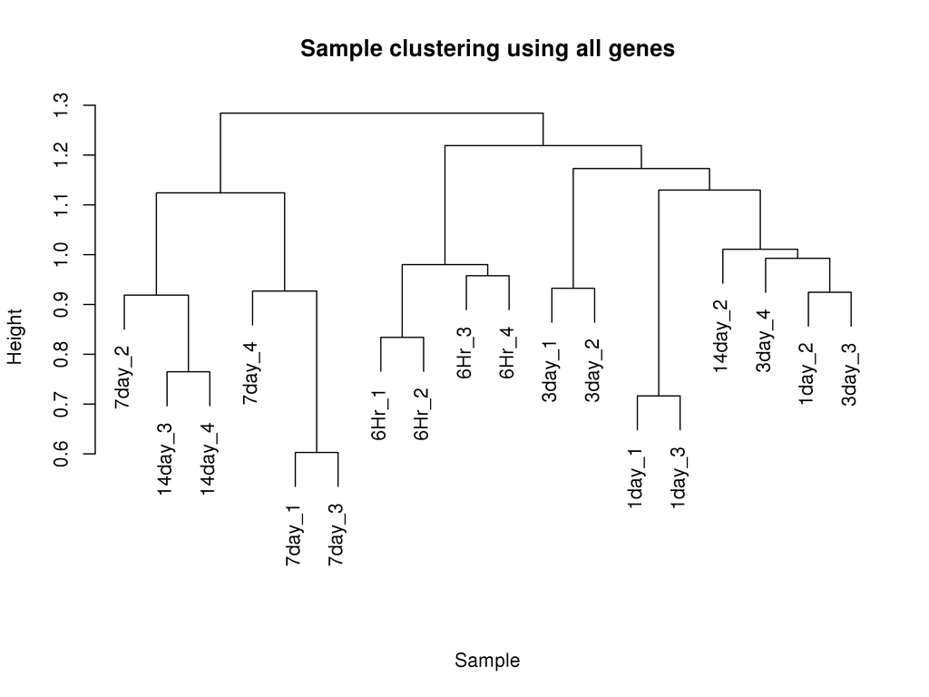

**Figure** Hierarchical clustering of samples using just selected genes.

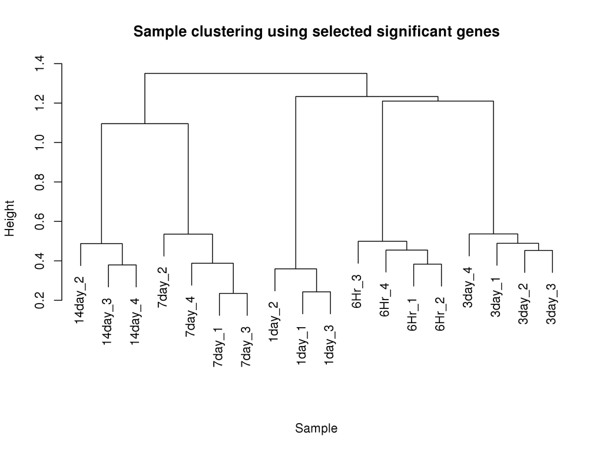

### Cluster selected genes

Genes selected by the last step were clustering using the following steps:

- Create a hierchical tree based on gene-gene correlation
- Cut the tree at height 1.6, which will classify genes into clusters. Then apply the following steps to refine the clusters
  - Calculate correlation of each gene to the centroid (median) of its cluster. Remove the genes if the correlation is less than 0.6
  - Remove clusters with size less than 20% of the expected size (the expected size is 50 if there are 500 genes and 10 clusters)
  - If there are less than 5 (the number of sample groups) clusters left, reduce the height cutoff by 0.05 and repeat this step until there are enough clusters
- Merge the 2 most similar clusters if the correlation of their centroids is greater than or equal to 0.6. Repeat this step until no 2 clusters are that similar

The initial analysis identified 7 gene clusters using just selected significant genes. A total of **720** genes were clustered.

**Figure** This plot shows below the average expression levels of each cluster. Values indicate number of standard deviation from mean of all samples.

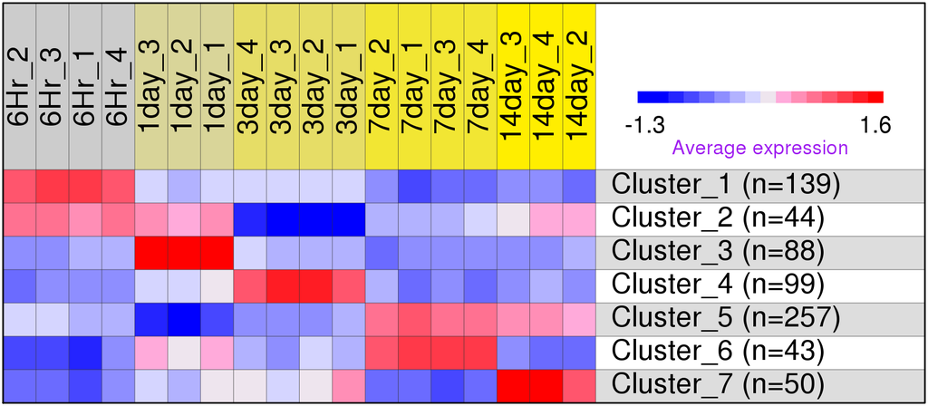

### Refine clusters

We further refine the gene clusters with the following steps:

- Select all 1454 genes with p values less than 0.02 to continue
- Assign selected genes to clusters:
  - Calculate centroid (median expression level of all genes in the cluster) of each cluster
  - Calculate correlation coefficient of each gene to centroid of each cluster to get a 1454 X 7 matrix
  - Assign a gene to a cluster if its correlation coefficient to the cluster is greater than 0.6, and the correlation coefficient to any other cluster is at least 0.2 less
  - Repeat this reclustering steps for 20 times unless the reclustering converged

The reclustering didn’t converge after 20 cycles.. A total of **751** genes were clustered.

**Figure** This plot shows below the average expression levels of each cluster after 20 cycles of reclustering. Values indicate number of standard deviation from mean of all samples.

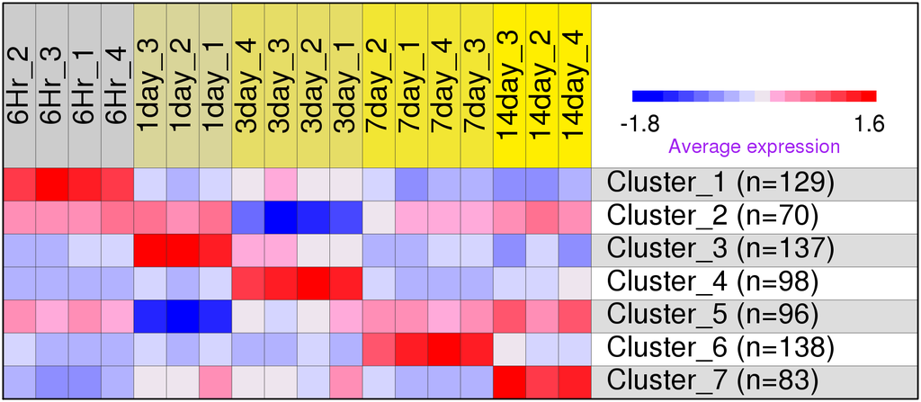

Result tables:

- Normalized expressiond data of clustered genes
  - Click here to view online
  - Click here to download table
- Statistical results of clustered genes
  - Click here to view online
  - Click here to download table

### Analysis of individual clusters

Click cluster names to see more detaied information about individual clusters

- Cluster_1
- Cluster_2
- Cluster_3
- Cluster_4
- Cluster_5
- Cluster_6
- Cluster_7

### Extra plots

**Figure** This plot traces the change of cluster sizes after each reclustering cycle.

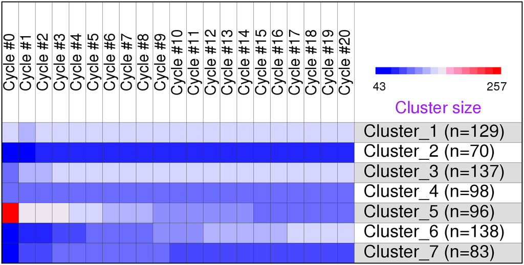

**Figure** Heatmap of all clustered genes

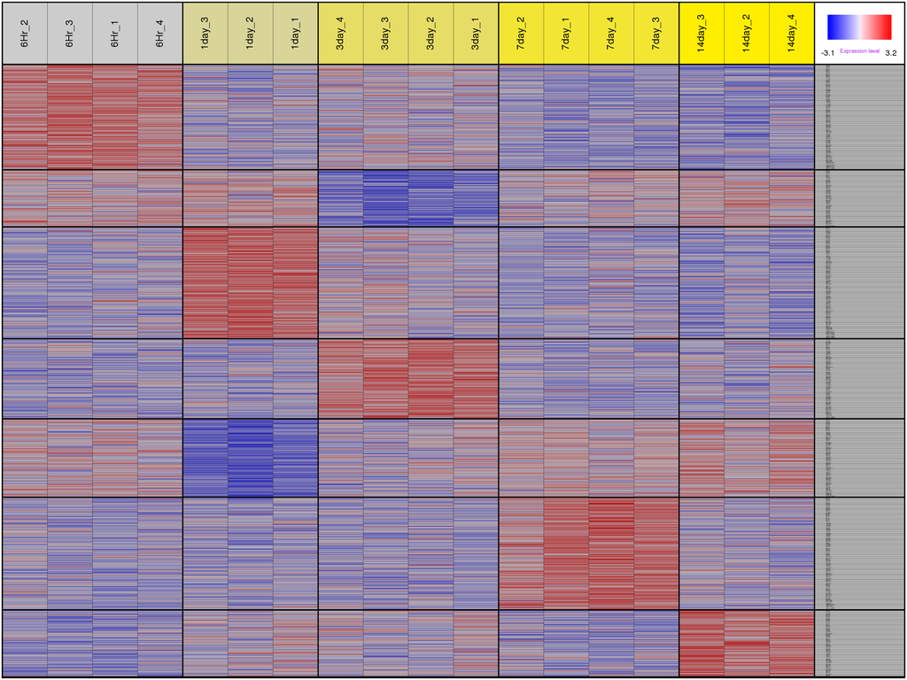

**Figure** Plot the group means and standard errors of all cluster together.

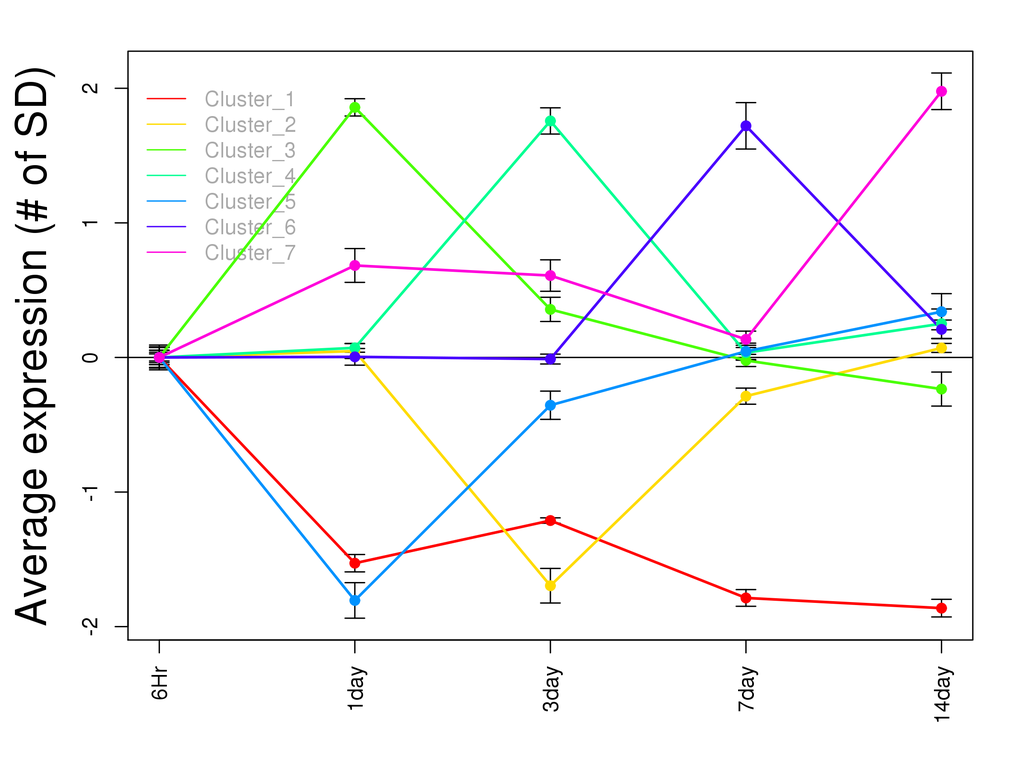

# Download all

Click here download all results as a .zip file

*END OF DOCUMENT*